# 02- Featurization of auto-mpg dataset

## Analysing car mpg data set using clustering and PCA

```python
# import libraries
import numpy as np
import pandas as pd

import matplotlib.pyplot as plt
%matplotlib inline
import seaborn as sns

from sklearn.model_selection import train_test_split

from sklearn.linear_model import LinearRegression
from sklearn.cluster import KMeans
```

```python
# warehouse the data
mpg_df = pd.read_csv('car-mpg.csv')

# checking the head
mpg_df.head()
```

|  | mpg | cyl | disp | hp | wt | acc | yr | origin | car_type | car_name |
| --- | --- | --- | --- | --- | --- | --- | --- | --- | --- | --- |
| 0 | 18.0 | 8 | 307.0 | 130 | 3504 | 12.0 | 70 | 1 | 0 | chevrolet chevelle malibu |
| 1 | 15.0 | 8 | 350.0 | 165 | 3693 | 11.5 | 70 | 1 | 0 | buick skylark 320 |
| 2 | 18.0 | 8 | 318.0 | 150 | 3436 | 11.0 | 70 | 1 | 0 | plymouth satellite |
| 3 | 16.0 | 8 | 304.0 | 150 | 3433 | 12.0 | 70 | 1 | 0 | amc rebel sst |
| 4 | 17.0 | 8 | 302.0 | 140 | 3449 | 10.5 | 70 | 1 | 0 | ford torino |

```python
# describe the data
mpg_df.describe().T
# horsepower is missing potentially due to bad values
```

|  | count | mean | std | min | 25% | 50% | 75% | max |
| --- | --- | --- | --- | --- | --- | --- | --- | --- |
| mpg | 398.0 | 23.514573 | 7.815984 | 9.0 | 17.500 | 23.0 | 29.000 | 46.6 |
| cyl | 398.0 | 5.454774 | 1.701004 | 3.0 | 4.000 | 4.0 | 8.000 | 8.0 |
| disp | 398.0 | 193.425879 | 104.269838 | 68.0 | 104.250 | 148.5 | 262.000 | 455.0 |
| wt | 398.0 | 2970.424623 | 846.841774 | 1613.0 | 2223.750 | 2803.5 | 3608.000 | 5140.0 |
| acc | 398.0 | 15.568090 | 2.757689 | 8.0 | 13.825 | 15.5 | 17.175 | 24.8 |
| yr | 398.0 | 76.010050 | 3.697627 | 70.0 | 73.000 | 76.0 | 79.000 | 82.0 |
| origin | 398.0 | 1.572864 | 0.802055 | 1.0 | 1.000 | 1.0 | 2.000 | 3.0 |
| car_type | 398.0 | 0.530151 | 0.499718 | 0.0 | 0.000 | 1.0 | 1.000 | 1.0 |

```python
isHpDigit = mpg_df['hp'].str.isdigit()
mpg_df[isHpDigit==False] # checking for bad values
```

|  | mpg | cyl | disp | hp | wt | acc | yr | origin | car_type | car_name |
| --- | --- | --- | --- | --- | --- | --- | --- | --- | --- | --- |
| 32 | 25.0 | 4 | 98.0 | ? | 2046 | 19.0 | 71 | 1 | 1 | ford pinto |
| 126 | 21.0 | 6 | 200.0 | ? | 2875 | 17.0 | 74 | 1 | 0 | ford maverick |
| 330 | 40.9 | 4 | 85.0 | ? | 1835 | 17.3 | 80 | 2 | 1 | renault lecar deluxe |
| 336 | 23.6 | 4 | 140.0 | ? | 2905 | 14.3 | 80 | 1 | 1 | ford mustang cobra |
| 354 | 34.5 | 4 | 100.0 | ? | 2320 | 15.8 | 81 | 2 | 1 | renault 18i |
| 374 | 23.0 | 4 | 151.0 | ? | 3035 | 20.5 | 82 | 1 | 1 | amc concord dl |

```python
mpg_df['hp'].replace({'?':np.nan},inplace=True)
```

```python
mpg_df['hp'] = mpg_df['hp'].astype('float64')
```

```python
# checking the info- data type, shape
mpg_df.info()
```

```
<class 'pandas.core.frame.DataFrame'>
RangeIndex: 398 entries, 0 to 397
Data columns (total 10 columns):
 #   Column    Non-Null Count  Dtype
---  ------    --------------  -----
 0   mpg       398 non-null    float64
 1   cyl       398 non-null    int64
 2   disp      398 non-null    float64
 3   hp        392 non-null    float64
 4   wt        398 non-null    int64
 5   acc       398 non-null    float64
 6   yr        398 non-null    int64
 7   origin    398 non-null    int64
 8   car_type  398 non-null    int64
 9   car_name  398 non-null    object
dtypes: float64(4), int64(5), object(1)
memory usage: 31.2+ KB
```

```python
med = mpg_df['hp'].median()
# replacing null values with median
mpg_df['hp'] = mpg_df['hp'].fillna(med)
```

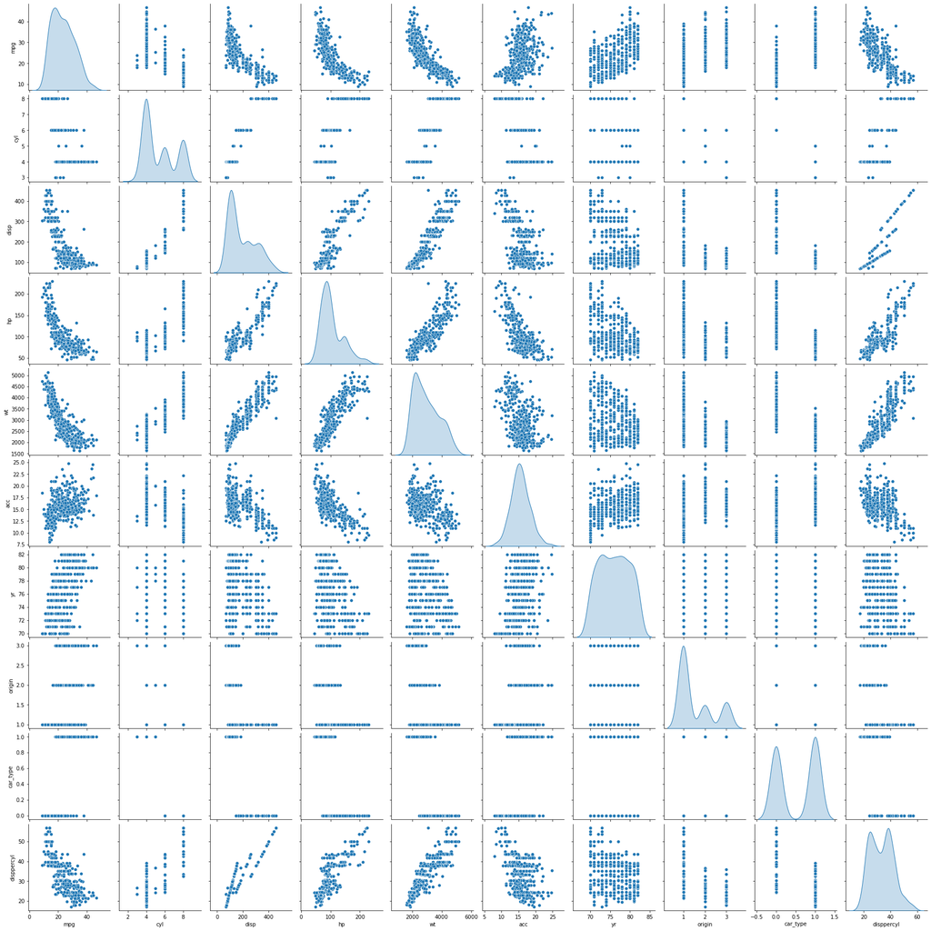

```python
mpg_df_attr = mpg_df.iloc[:,0:9]

# feature creation
mpg_df_attr['disppercyl'] = mpg_df_attr['disp'] / mpg_df_attr['cyl']

sns.pairplot(mpg_df_attr,diag_kind='kde')
```

### Observations:

- Seeing the **kde** plot we can see multiple peaks, meaning there are `atleast` **3 Guassian Combined** or **3 clusters**.
- Here range of clusters can be **3 to 9**, on multiplying different peaks in **kde**.
- Seems `acc` has very little effect on `mpg`, so we can drop this column

```python
from scipy.stats import zscore # for scaling
```

### Iteration 1

using all columns of original dataset

```python
mpg_df_attr = mpg_df.loc[:, 'mpg':'origin']
mpg_df_attr_z = mpg_df_attr.apply(zscore)

mpg_df_attr_z.pop('origin')      # Remove "origin" and "yr" columns
mpg_df_attr_z.pop('yr') # no strong relationship

array = mpg_df_attr_z.values
X = array[:,1:] # select all rows and columns except mpg
y = array[:,0]   # select all rows and mpg column
X_train, X_test, y_train, y_test = train_test_split(X, y, test_size=0.30, random_state=1)
```

```python
from sklearn.svm import SVR
```

```python
clr = SVR() # instantiate model
```

```python
clr.fit(X_train,y_train) # fit train data
```

```
SVR()
```

```python
y_pred = clr.predict(X_test) # predict on test data
```

```python
# R^2 score on test
clr.score(X_test,y_test)
```

```
0.8004011099311668
```

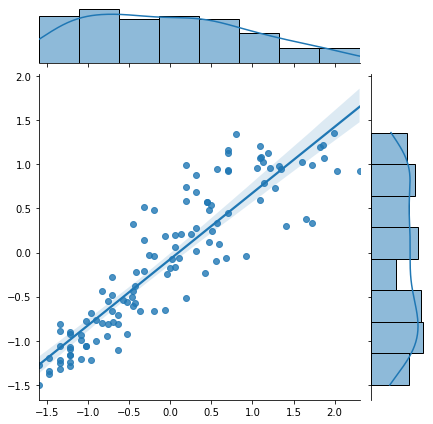

```python
# compare predicted vs test
sns.jointplot(x=y_test,y=y_pred,kind='reg')
```

### Iteration 2

Dropping some columns

```python
# 1. Drop acc column based on the above visual analysis

mpg_df_attr_z.pop('acc')

array = mpg_df_attr_z.values
X = array[:,1:] # select all rows except mpg
y = array[:,0]   # select all rows and mpg column
X_train, X_test, y_train, y_test = train_test_split(X, y, test_size=0.30, random_state=1)
```

```python
# model building
clr.fit(X_train , y_train)
y_pred = clr.predict(X_test) # prediction
```

```python
# R^2 score on test
clr.score(X_test,y_test)
```

```
0.7872884170162795
```

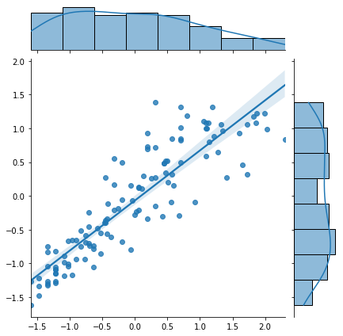

```python
# compare predicted vs test
sns.jointplot(x=y_test,y=y_pred,kind='reg')
```

### Observations:

- **R^2** has reduced but not significantly, this means that `acc` didn't have much **predictive power** for `mpg`.

### Finding Hidden Patterns

#### Using KMeans Clustering

```python
cluster_range = range(1, 10)   # expect 3 to 4 clusters from the pair panel visual inspection hence restricting from 2 to 9
cluster_errors = []
for num_clusters in cluster_range:
  clusters = KMeans( num_clusters, n_init = 5)
  clusters.fit(mpg_df_attr)
  labels = clusters.labels_
  centroids = clusters.cluster_centers_
  cluster_errors.append( clusters.inertia_ )
clusters_df = pd.DataFrame( { "num_clusters":cluster_range, "cluster_errors": cluster_errors } )
clusters_df
```

|  | num_clusters | cluster_errors |
| --- | --- | --- |
| 0 | 1 | 2.896353e+08 |
| 1 | 2 | 7.428960e+07 |
| 2 | 3 | 3.420817e+07 |
| 3 | 4 | 1.905669e+07 |
| 4 | 5 | 1.376977e+07 |
| 5 | 6 | 1.032052e+07 |
| 6 | 7 | 7.662878e+06 |
| 7 | 8 | 5.662080e+06 |
| 8 | 9 | 4.734460e+06 |

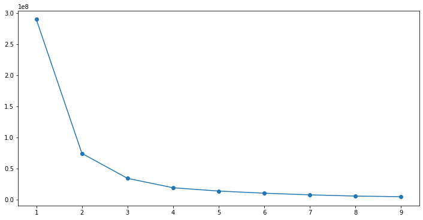

```python
# Elbow plot

plt.figure(figsize=(12,6))
plt.plot( clusters_df.num_clusters, clusters_df.cluster_errors, marker = "o" )
```

So from **Elbow Method** it is evident there must be atleast **3** clusters.

**k = 3**

```python
mpg_df_attr = mpg_df.loc[:, 'mpg':'origin']
mpg_df_attr_z = mpg_df_attr.apply(zscore)

cluster = KMeans( n_clusters = 3, random_state = 2354 )
cluster.fit(mpg_df_attr_z)

prediction=cluster.predict(mpg_df_attr_z)
mpg_df_attr_z["GROUP"] = prediction     # Creating a new column "GROUP" which will hold the cluster id of each record

mpg_df_attr_z_copy = mpg_df_attr_z.copy(deep = True)  # Creating a mirror copy for later re-use instead of building repeatedly
```

```python
centroids = cluster.cluster_centers_
centroids
```

```
array([[-1.12726026,  1.4864187 ,  1.46865697,  1.47338845,  1.36736404,
        -1.03371846, -0.61198576, -0.71514478],
       [ 0.89844152, -0.81610375, -0.86426529, -0.70547867, -0.86985567,
         0.27002569,  0.31010992,  0.95968268],
       [-0.23301503, -0.12590632, -0.05634295, -0.24639985,  0.02416321,
         0.43720956,  0.08226919, -0.60579879]])
```

```python
centroid_df = pd.DataFrame(centroids, columns = list(mpg_df_attr) )
centroid_df
```

|  | mpg | cyl | disp | hp | wt | acc | yr | origin |
| --- | --- | --- | --- | --- | --- | --- | --- | --- |
| 0 | -1.127260 | 1.486419 | 1.468657 | 1.473388 | 1.367364 | -1.033718 | -0.611986 | -0.715145 |
| 1 | 0.898442 | -0.816104 | -0.864265 | -0.705479 | -0.869856 | 0.270026 | 0.310110 | 0.959683 |
| 2 | -0.233015 | -0.125906 | -0.056343 | -0.246400 | 0.024163 | 0.437210 | 0.082269 | -0.605799 |

```
array([[<AxesSubplot:title={'center':'acc'}, xlabel='[GROUP]'>,
        <AxesSubplot:title={'center':'cyl'}, xlabel='[GROUP]'>,
        <AxesSubplot:title={'center':'disp'}, xlabel='[GROUP]'>,
        <AxesSubplot:title={'center':'hp'}, xlabel='[GROUP]'>],
       [<AxesSubplot:title={'center':'mpg'}, xlabel='[GROUP]'>,
        <AxesSubplot:title={'center':'origin'}, xlabel='[GROUP]'>,
        <AxesSubplot:title={'center':'wt'}, xlabel='[GROUP]'>,
        <AxesSubplot:title={'center':'yr'}, xlabel='[GROUP]'>]],
      dtype=object)
```

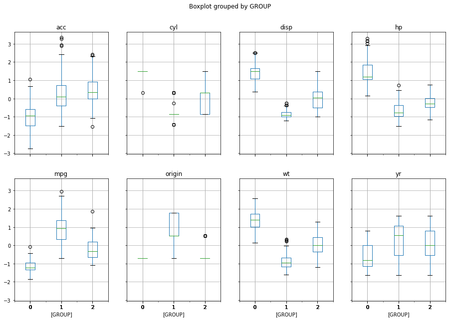

```python
mpg_df_attr_z.boxplot(by = 'GROUP',  layout=(2,4), figsize=(15, 10))
```

- There are many outliers on each dimension (indicated by the black circles).
- Spread of data on each dimension (indicated by the whiskers is long ... due to the outliers).
- If the outliers are addressed, the clusters will overlap much less than right now (except in year dimension which has no outlier)

### Identifying and Handling outliers

```python
# Addressing outliers at group level

data = mpg_df_attr_z   # lazy to type long names. Renaming it to data. Remember data is not a copy of the dataframe

def replace(group):
    median, std = group.median(), group.std()  #Get the median and the standard deviation of every group
    outliers = (group - median).abs() > 2*std # Subtract median from every member of each group. Take absolute values > 2std
    group[outliers] = group.median()
    return group

data_corrected = (data.groupby('GROUP').transform(replace))
concat_data = data_corrected.join(pd.DataFrame(mpg_df_attr_z['GROUP']))
concat_data.head()
```

|  | mpg | cyl | disp | hp | wt | acc | yr | origin | GROUP |
| --- | --- | --- | --- | --- | --- | --- | --- | --- | --- |
| 0 | -0.706439 | 1.498191 | 1.090604 | 0.673118 | 0.630870 | -1.295498 | -1.627426 | -0.715145 | 0 |
| 1 | -1.090751 | 1.498191 | 1.503514 | 1.589958 | 0.854333 | -1.477038 | -1.627426 | -0.715145 | 0 |
| 2 | -0.706439 | 1.498191 | 1.196232 | 1.197027 | 0.550470 | -1.658577 | -1.627426 | -0.715145 | 0 |
| 3 | -0.962647 | 1.498191 | 1.061796 | 1.197027 | 0.546923 | -1.295498 | -1.627426 | -0.715145 | 0 |
| 4 | -0.834543 | 1.498191 | 1.042591 | 0.935072 | 0.565841 | -1.840117 | -1.627426 | -0.715145 | 0 |

```
array([[<AxesSubplot:title={'center':'acc'}, xlabel='[GROUP]'>,
        <AxesSubplot:title={'center':'cyl'}, xlabel='[GROUP]'>,
        <AxesSubplot:title={'center':'disp'}, xlabel='[GROUP]'>,
        <AxesSubplot:title={'center':'hp'}, xlabel='[GROUP]'>],
       [<AxesSubplot:title={'center':'mpg'}, xlabel='[GROUP]'>,
        <AxesSubplot:title={'center':'origin'}, xlabel='[GROUP]'>,
        <AxesSubplot:title={'center':'wt'}, xlabel='[GROUP]'>,
        <AxesSubplot:title={'center':'yr'}, xlabel='[GROUP]'>]],
      dtype=object)
```

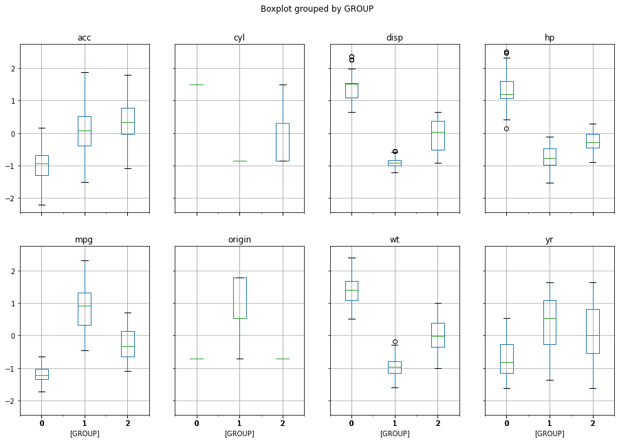

```python
concat_data.boxplot(by = 'GROUP', layout=(2,4), figsize=(15, 10))
```

**Note**: When we remove outliers and replace with median or mean, the distribution shape changes, the standard deviation becomes tighter creating new outliers. The new outliers would be much closer to the centre than original outliers so we accept them without modifying them

### Let us analyze the mpg column vs other columns group wise

```python
def plot_regression(var):
    sns.lmplot(x=var,y='mpg',data=concat_data,hue='GROUP')
```

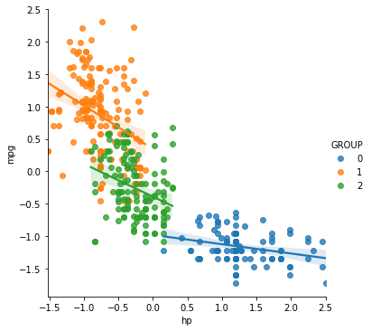

```python
# mpg Vs hp
plot_regression('hp')
```

- For **Group 0**, `hp` is weak predictor of `mpg` because of the line seems parallel to `hp`.
- So `hp` can't be used as a good predictor of `mpg`.

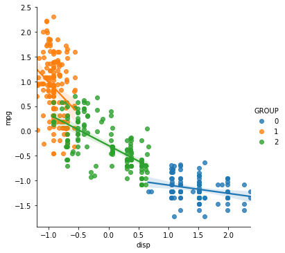

```python
plot_regression('disp')
```

- For **Group 0**, `disp` is weak predictor of `mpg` because of the line seems parallel to `disp`.
- So `disp` can't be used as a good predictor of `disp`.

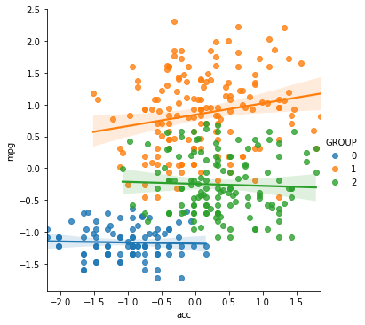

```python
plot_regression('acc')
```

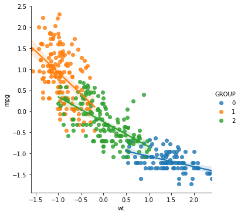

```python
plot_regression('wt')
```

- For **Group 0**, `wt` is weak predictor of `mpg` because of the line seems parallel to `wt`.
- So `wt` can't be used as a good predictor of `mpg`.

### Observations:

- We might build different models for different clusters based on different features.
- There is high variance because values from source(car manufacturer) and dataset differ a lot.

For **feature selection** we might do:

- **DecisionTreeRegressor** and choose features of importance.
- **PCA** and select few features explainign variance of data.
- **Lasso Regression** to drop certain columns.

```python
mpg_df_attr = mpg_df.iloc[:, 0:9]
mpg_df_attr['dispercyl'] = mpg_df_attr['disp'] / mpg_df_attr['cyl']

mpg_df_attr_z = mpg_df_attr.apply(zscore)
mpg_df_attr_z.pop('origin')      # Remove "origin" and "yr" columns
mpg_df_attr_z.pop('yr')

array = mpg_df_attr_z.values
X = array[:,1:5] # select all rows except mpg, acc
y = array[:,0]   # select all rows and mpg column
X_train, X_test, y_train, y_test = train_test_split(X, y, test_size=0.30, random_state=1)
```

```python
from sklearn.tree import DecisionTreeRegressor
```

```python
regressor = DecisionTreeRegressor(random_state=0, max_depth=3)

regressor.fit(X_train , y_train)
feature_importances = regressor.feature_importances_


feature_names = mpg_df_attr.columns[1:9]
print(feature_names)
print()
k = 8

print(feature_importances)
top_k_idx = (feature_importances.argsort()[-k:][::-1])
print()
print(feature_names[top_k_idx], feature_importances)
```

```
Index(['cyl', 'disp', 'hp', 'wt', 'acc', 'yr', 'origin', 'car_type'], dtype='object')

[0.74791504 0.01157464 0.19724952 0.04326079]

Index(['cyl', 'hp', 'wt', 'disp'], dtype='object') [0.74791504 0.01157464 0.19724952 0.04326079]
```

```python
y_pred = regressor.predict(X_test)
```

```python
regressor.score(X_test,y_test)
```

```
0.7394218507497639
```

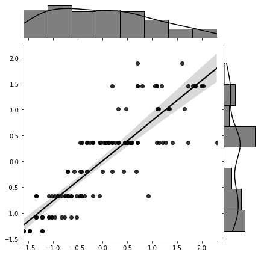

```python
sns.jointplot(x=y_test, y=y_pred, kind="reg", color="k")
```

DecisionTree with atrributes of high importance

```python
# 1. Drop column based on the above feature importance analysis

X = mpg_df_attr_z.drop( ['mpg','acc', 'car_type', 'dispercyl' ] , axis=1)
y = mpg_df_attr_z['mpg']


X_train, X_test, y_train, y_test = train_test_split(X, y, test_size=0.30, random_state=1)
```

```python
regressor.fit(X_train , y_train)
y_pred = regressor.predict(X_test)

regressor.feature_importances_

print (pd.DataFrame(regressor.feature_importances_, columns = ["Imp"], index = X_train.columns))
```

```
           Imp
cyl   0.747915
disp  0.011575
hp    0.197250
wt    0.043261
```

```python
y_pred = regressor.predict(X_test)
```

```python
regressor.score(X_test,y_test)
```

```
0.7394218507497639
```

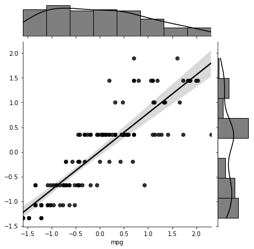

```python
sns.jointplot(x=y_test, y=y_pred, kind="reg", color="k")
```

### We can further go for Ridge and Lasso Regression

Even then if we model is achieving the required score, we can start building complex models, like Use `PolynomialFeatures`